# Quando usar modelo misto (e quando não)

## 6 Caso estudo: expressão de ESR2 com réplicas biológicas desbalanceadas

### 6.1 Por que esse desenho experimental exige modelo misto

Suponha que você mediu a expressão do gene **ESR2** em células T47D sob três condições:

- T47D (controle)
- T47D tratado com 4OHT
- T47D tratado com 4OHT + E2 (estradiol)

Cada condição tem três réplicas biológicas, mas o número de medidas técnicas por réplica varia:

- Réplica 1: quintuplicata (5 medidas técnicas)
- Réplica 2: quadruplicata (4 medidas técnicas)
- Réplica 3: quadruplicata (4 medidas técnicas)

Total: 13 medidas por tratamento, 39 observações no banco de dados.

E um desenho comum na prática de experimentos de bancada. O resultado é um conjunto de dados **desbalanceado** em que as réplicas biológicas têm pesos diferentes.

### 6.2 Estrutura dos dados

```r
# Construção do banco de dados de expressão de ESR2
# Os valores da primeira réplica (quintuplicata) do tratamento
# T47D 4OHT+E2 são os dados reais do experimento. Os demais foram
# inventados.

esr2 <- tibble::tibble(
  Tratamento = rep(
    c("T47D", "T47D_4OHT", "T47D_4OHT_E2"),
    each = 13
  ),
  BioReplica = rep(
    rep(c("BioRep1", "BioRep2", "BioRep3"),
        times = c(5, 4, 4)),
    times = 3
  ),
  Expressao = c(
    # ---- T47D (controle: expressão basal em torno de 1) ----
    # BioRep1: quintuplicata (5 técnicas)
    1.18, 1.05, 0.96, 0.82, 1.20,
    # BioRep2: quadruplicata (4 técnicas)
    0.85, 0.91, 0.88, 0.94,
    # BioRep3: quadruplicata (4 técnicas)
    1.05, 0.95, 1.10, 1.02,

    # ---- T47D + 4OHT ----
    # BioRep1: quintuplicata (5 técnicas)
    0.70, 0.68, 0.72, 0.65, 0.71,
    # BioRep2: quadruplicata (4 técnicas)
    0.55, 0.58, 0.60, 0.57,
    # BioRep3: quadruplicata (4 técnicas)
    0.88, 0.92, 0.85, 0.90,

    # ---- T47D + 4OHT + E2 ----
    # BioRep1: quintuplicata (5 técnicas) -- dados reais do experimento
    3.05, 2.69, 2.75, 3.39, 2.83,
    # BioRep2: quadruplicata (4 técnicas)
    2.90, 3.10, 2.95, 3.05,
    # BioRep3: quadruplicata (4 técnicas)
    3.40, 3.55, 3.45, 3.50
  )
) %>%
  mutate(
    BioReplica = factor(
      BioReplica,
      levels = c("BioRep1", "BioRep2", "BioRep3")
    ),
    Tratamento = factor(
      Tratamento,
      levels = c("T47D", "T47D_4OHT", "T47D_4OHT_E2")
    )
  )

esr2 %>%
  count(Tratamento, BioReplica) %>%
  pivot_wider(names_from = BioReplica, values_from = n)
```

| Tratamento | BioRep1 | BioRep2 | BioRep3 |
| --- | --- | --- | --- |
| T47D | 5 | 4 | 4 |
| T47D_4OHT | 5 | 4 | 4 |
| T47D_4OHT_E2 | 5 | 4 | 4 |

A tabela acima confirma o desenho: BioRep1 tem 5 medidas, BioRep2 e BioRep3 têm 4, em cada tratamento.

### 6.3 Visualização

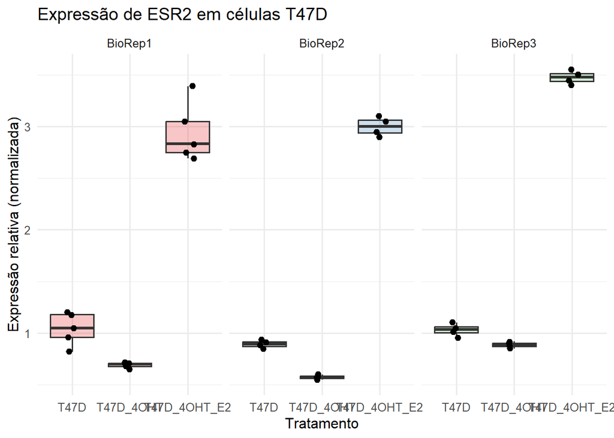

```r
esr2 %>%
  ggplot(aes(x = Tratamento, y = Expressao, fill = BioReplica)) +
  geom_boxplot(alpha = 0.25, outlier.shape = NA) +
  geom_jitter(width = 0.12, size = 2) +
  facet_wrap(~BioReplica) +
  scale_fill_brewer(palette = "Set1", guide = "none") +
  labs(
    title = "Expressão de ESR2 em células T47D",
    x = "Tratamento",
    y = "Expressão relativa (normalizada)",
    colour = "Réplica biológica"
  ) +
  theme_minimal(base_size = 12)
```

Cada réplica biológica tem sua própria “linha de base”, note como BioRep1, BioRep2 e BioRep3 ocupam faixas diferentes dentro de cada tratamento. Essa é a assinatura de dados com efeito aleatório de réplica: as réplicas se deslocam como blocos, e as comparações relevantes são **dentro** de cada réplica, não entre todas as observações como se fossem independentes.

### 6.4 O problema de tratar todas as medidas como independentes

Se você ignorar a estrutura de réplicas e rodar uma ANOVA simples (ou `lm`) tratando as 39 medidas como independentes:

```r
# Abordagem incorreta: ignorar que muitas medidas vêm da mesma réplica
m_anova <- lm(Expressao ~ Tratamento, data = esr2)
summary(m_anova)
```

```
Call:
lm(formula = Expressao ~ Tratamento, data = esr2)

Residuals:
     Min       1Q   Median       3Q      Max
-0.43385 -0.12615 -0.03308  0.14885  0.42615

Coefficients:
                       Estimate Std. Error t value Pr(>|t|)
(Intercept)             0.99308    0.05589  17.767  < 2e-16 ***
TratamentoT47D_4OHT    -0.27692    0.07905  -3.503  0.00125 **
TratamentoT47D_4OHT_E2  2.13077    0.07905  26.956  < 2e-16 ***
---
Signif. codes:  0 '***' 0.001 '**' 0.01 '*' 0.05 '.' 0.1 ' ' 1

Residual standard error: 0.2015 on 36 degrees of freedom
Multiple R-squared:  0.9686,    Adjusted R-squared:  0.9669
F-statistic: 555.6 on 2 and 36 DF,  p-value: < 2.2e-16
```

### 6.5 Modelo misto: réplica biológica como efeito aleatório

```r
library(lme4)
library(lmerTest)

# Modelo misto: efeito fixo do tratamento + intercepto aleatório por réplica
m_misto <- lmer(
  Expressao ~ Tratamento + (1 | BioReplica),
  data = esr2
)
summary(m_misto)
```

```
Linear mixed model fit by REML. t-tests use Satterthwaite's method [
lmerModLmerTest]
Formula: Expressao ~ Tratamento + (1 | BioReplica)
   Data: esr2

REML criterion at convergence: -18.6

Scaled residuals:
     Min       1Q   Median       3Q      Max
-2.46734 -0.37646 -0.01172  0.35495  2.01790

Random effects:
 Groups     Name        Variance Std.Dev.
 BioReplica (Intercept) 0.02394  0.1547
 Residual               0.02436  0.1561
Number of obs: 39, groups:  BioReplica, 3

Fixed effects:
                       Estimate Std. Error       df t value Pr(>|t|)
(Intercept)             0.99714    0.09929  2.59678  10.042  0.00379 **
TratamentoT47D_4OHT    -0.27692    0.06121 33.98280  -4.524 7.06e-05 ***
TratamentoT47D_4OHT_E2  2.13077    0.06121 33.98280  34.808  < 2e-16 ***
---
Signif. codes:  0 '***' 0.001 '**' 0.01 '*' 0.05 '.' 0.1 ' ' 1

Correlation of Fixed Effects:
            (Intr) TrT47D_4OHT
TrT47D_4OHT -0.308
TT47D_4OHT_ -0.308  0.500
```

```r
# Modelo misto: efeito fixo do tratamento + intercepto aleatório por réplica
m_lm_bioreplic_fixo <- lm(
  Expressao ~ Tratamento + BioReplica,
  data = esr2
)
summary(m_lm_bioreplic_fixo)
```

```
Call:
lm(formula = Expressao ~ Tratamento + BioReplica, data = esr2)

Residuals:
     Min       1Q   Median       3Q      Max
-0.38149 -0.05272  0.00487  0.06208  0.31851

Coefficients:
                       Estimate Std. Error t value Pr(>|t|)
(Intercept)             0.94072    0.05359  17.553  < 2e-16 ***
TratamentoT47D_4OHT    -0.27692    0.06121  -4.524 7.04e-05 ***
TratamentoT47D_4OHT_E2  2.13077    0.06121  34.813  < 2e-16 ***
BioReplicaBioRep2      -0.06867    0.06044  -1.136 0.263831
BioReplicaBioRep3       0.23883    0.06044   3.952 0.000372 ***
---
Signif. codes:  0 '***' 0.001 '**' 0.01 '*' 0.05 '.' 0.1 ' ' 1

Residual standard error: 0.156 on 34 degrees of freedom
Multiple R-squared:  0.9822,    Adjusted R-squared:  0.9801
F-statistic: 469.8 on 4 and 34 DF,  p-value: < 2.2e-16
```

Agora a variância é particionada:

- **Variância do intercepto aleatório** (BioReplica): quanto as réplicas biológicas diferem entre si, em média, independentemente do tratamento.
- **Variância residual**: o que sobra dentro de cada réplica, ruído técnico das replicates técnicas.

O efeito fixo de `Tratamento` é estimado a partir da variação **dentro** de cada réplica biológica. É esse o sinal que importa: **a expressão de ESR2 muda com o tratamento e, quando coloco réplica biológica como efeito aletatório, eu estou controlando a variação do efeito dos tratamentos entre réplicas.**

### 6.6 Comparando os dois erros-padrão

```r
tidy_misto <- broom.mixed::tidy(m_misto, effects = "fixed")

tidy_misto %>%
  select(term, estimate, std.error, df, p.value) %>%
  mutate(
    term = case_when(
      term == "(Intercept)" ~ "T47D (referência)",
      term == "TratamentoT47D_4OHT" ~ "T47D 4OHT vs T47D",
      term == "TratamentoT47D_4OHT_E2" ~ "T47D 4OHT+E2 vs T47D",
      TRUE ~ term
    )
  )
```

| term | estimate | std.error | df | p.value |
| --- | --- | --- | --- | --- |
| T47D (referência) | 0.9971415 | 0.09929246 | 2.596781 | 3.794220e-03 |
| T47D 4OHT vs T47D | -0.2769231 | 0.06121470 | 33.982801 | 7.061740e-05 |
| T47D 4OHT+E2 vs T47D | 2.1307692 | 0.06121470 | 33.982801 | 3.649833e-28 |

Note como o erro-padrão no modelo misto reflete apenas a variação que sobra **depois de contabilizar** a diferença entre réplicas. Se as réplicas biológicas forem consistentes no efeito do tratamento (ou seja, se o efeito for robusto), o modelo misto terá poder para detectá-lo. Se cada réplica tiver um comportamento muito diferente, a variância do intercepto aleatório vai ser grande e o modelo misto será conservador, o que é correto, porque você não tem evidência consistente.

### 6.7 O que o modelo misto nunca fará

O modelo misto **não estima** o efeito de cada réplica biológica individualmente. Ele assume que as três réplicas são uma amostra de uma população maior de réplicas que poderiam ter sido feitas, e estima a variância dessa população aleatorizada. Isso é exatamente o que você quer quando:

- Suas réplicas são amostras de um processo biológico contínuo (diferentes passagens celulares, diferentes datas de experimento).
- Você quer generalizar o resultado para o que aconteceria com novas réplicas, não apenas para as três que fez.

Se, em vez disso, as três réplicas fossem **todas as réplicas que existem** (por exemplo, três doenadores únicos em um estudo clínico, e você quer estimar o efeito para cada um), então o efeito de réplica seria fixo, e aí o modelo misto não seria a escolha certa. O checklist do início do módulo ajuda a decidir entre esses dois casos.

### 6.8 Resumo do exemplo

| Situação | Abordagem | Por quê |
| --- | --- | --- |
| Todas as 39 medidas tratadas como independentes | `llm(Expressao ~ Tratamento)` | Ignora que medidas da mesma réplica são correlacionadas, **não recomendado** |
| Réplicas como amostra de população, quer generalizar | `lmer(Expressao ~ Tratamento + (1 \\| BioReplica))` | Particiona variância biológica vs. técnica, **correto para este desenho** |
| Só três réplicas que existem e quer estimar cada uma | `lm(Expressao ~ Tratamento + BioReplica)` | Cada réplica é um nível fixo estimado individualmente |

## 7 Abordagem alternativa: média por réplica biológica seguida de ANOVA

Além de tratar todas as 39 medidas como independentes (o erro discutido acima) e do modelo misto, há uma terceira estratégia que alguns pesquisadores adotam na prática de bancada: calcular a média de cada réplica biológica em cada tratamento e, em seguida, rodar uma ANOVA (ou teste t) sobre esses valores médios, usando o número de réplicas como unidade de análise.

Essa estratégia é muito comum porque parece resolver o problema da pseudoreplicação: em vez de 39 observações, o pesquisador passa a ter 3 observações por tratamento (as médias das três réplicas biológicas). O erro-padrão é calculado sobre as três réplicas, e não sobre as cinco medidas técnicas, o que evita o artificialismo do modelo `lm` (ANOVA ingênua).

Vamos ver como isso funciona com os dados de ESR2.

### 7.1 Calculando a média por réplica biológica e por tratamento

```r
media_replica <- esr2 %>%
  group_by(Tratamento, BioReplica) %>%
  summarise(
    media = mean(Expressao),
    n_medidas = n(),
    .groups = "drop"
  )

media_replica
```

| Tratamento | BioReplica | media | n_medidas |
| --- | --- | --- | --- |
| T47D | BioRep1 | 1.0420 | 5 |
| T47D | BioRep2 | 0.8950 | 4 |
| T47D | BioRep3 | 1.0300 | 4 |
| T47D_4OHT | BioRep1 | 0.6920 | 5 |
| T47D_4OHT | BioRep2 | 0.5750 | 4 |
| T47D_4OHT | BioRep3 | 0.8875 | 4 |
| T47D_4OHT_E2 | BioRep1 | 2.9420 | 5 |
| T47D_4OHT_E2 | BioRep2 | 3.0000 | 4 |
| T47D_4OHT_E2 | BioRep3 | 3.4750 | 4 |

Esse tibble tem exatamente 9 linhas: 3 tratamentos × 3 réplicas = 9 combinações, cada uma com sua média de expressão.

### 7.2 ANOVA sobre as médias das réplicas

Agora que temos 3 observações por tratamento (as médias de BioRep1, BioRep2 e BioRep3), podemos rodar uma ANOVA:

```r
# ANOVA com médias das réplicas como unidade de análise
m_anova_media <- lm(media ~ Tratamento, data = media_replica)
summary(m_anova_media)
```

```
Call:
lm(formula = media ~ Tratamento, data = media_replica)

Residuals:
     Min       1Q   Median       3Q      Max
-0.19700 -0.13900 -0.02617  0.05300  0.33600

Coefficients:
                       Estimate Std. Error t value Pr(>|t|)
(Intercept)              0.9890     0.1141   8.670  0.00013 ***
TratamentoT47D_4OHT     -0.2708     0.1613  -1.679  0.14418
TratamentoT47D_4OHT_E2   2.1500     0.1613  13.328  1.1e-05 ***
---
Signif. codes:  0 '***' 0.001 '**' 0.01 '*' 0.05 '.' 0.1 ' ' 1

Residual standard error: 0.1976 on 6 degrees of freedom
Multiple R-squared:  0.9783,    Adjusted R-squared:  0.9711
F-statistic: 135.2 on 2 and 6 DF,  p-value: 1.023e-05
```

O que esse modelo está fazendo:

- Ele compara as 3 médias de cada grupo de tratamento, usando as diferenças entre essas 3 médias como base para o erro-padrão.
- O número de graus de liberdade para o erro é 6 (9 observações − 3 grupos).
- O teste F pergunta: as médias das réplicas são diferentes entre tratamentos?

### 7.3 O que essa ANOVA está realmente estimando

Essa ANOVA sobra o quê?

- Ela **respeita a estrutura de replicação biológica**: como as médias são calculadas dentro de cada réplica, as comparações entre tratamentos são feitas sobre a variação entre réplicas, não sobre a variação entre medidas técnicas.
- Isso é correcto em um sentido importante: a réplica biológica é a unidade de amostragem que você quer usar para generalizar. Se você repetisse o experimento com novas réplicas, as médias das novas réplicas teriam variação comparáveis à variação entre as 3 réplicas atuais.
- O teste F e o p-valor refletem a variabilidade **entre réplicas**, não a variabilidade entre medidas técnicas.

Então, em que sentido essa ANOVA sobre médias está correta e em que sentido está incompleta?

### 7.4 Quando a ANOVA sobre médias das réplicas é uma escolha razoável

- Quando você coleta réplicas biológicas que são **verdadeiramente independentes** (diferentes lotes de células, diferentes semanas, diferentes operadores) e o objetivo é generalizar para o que aconteceria com novas réplicas.
- Quando o número de réplicas é suficiente para que o teste tenha poder (3 réplicas é pouco; 5 ou mais começa a ser mais confiável).
- Quando você não precisa distinguir a variação técnica (dentro da réplica) da variação biológica (entre réplicas), porque o foco é a conclusão sobre o tratamento em nível de réplica.

Nesses casos, a ANOVA sobre médias é defensável e seus resultados serão similares aos do modelo misto — ambos tratam a réplica como unidade de análise.

### 7.5 Quando a ANOVA sobre médias das réplicas perde informação

- Quando as réplicas têm pesos diferentes (BioRep1 tem 5 medidas, BioRep2 e BioRep3 têm 4). A média de BioRep1 é mais precisa (menos ruído técnico) do que as médias de BioRep2 e BioRep3, mas a ANOVA trata todas as 9 médias como igualmente confiáveis.
- Quando o número de réplicas é pequeno (como aqui, 3 por grupo), o poder do teste é limitado e a ANOVA pode não detectar um efeito que o modelo misto detectaria, porque o modelo misto usa as medidas técnicas extras para estimar melhor a variância residual dentro da réplica.
- Quando o pesquisador quer saber tanto o efeito do tratamento quanto a variação técnica que ele espera ver em uma nova réplica. A ANOVA sobre médias só responde a pergunta de tratamento, não a de variabilidade.

### 7.6 Comparação com o modelo misto

O modelo misto feito anteriormente (bloco `modelo-misto-esr2`) e a ANOVA sobre médias fazem perguntas similares: “o tratamento afeta a expressão de ESR2 quando controlamos a variação entre réplicas?” mas respondem de forma ligeiramente diferente:

- O **modelo misto** usa todas as 39 medidas: as 5 medidas de BioRep1 em T47D 4OHT+E2 informam tanto a estimativa do efeito do tratamento quanto a estimativa da variância dentro da réplica. Ele “ouve” melhor a sinal quando as réplicas são consistentes. Ou seja, ele nao ignora a dependência das réplicas técnicas dentro da mesma réplica biológica. Ou seja *o modelo “sabe” que as 5 medidas de BioRep1 têm o mesmo intercepto, e portanto não as conta 5 vezes para o efeito do tratamento.*
- A **ANOVA sobre médias** usa apenas as 9 médias das réplicas. Ela “ouve” apenas a variação entre réplicas, ignorando a informação extra que as medidas técnicas dão sobre a confiança de cada média.

Em um experimento com muitas réplicas (digamos, 10 por grupo) e poucas medidas técnicas por réplica, as duas abordagens convergem: ambas tratam a réplica como unidade de análise. Em um experimento com poucas réplicas e muitas medidas técnicas (como aqui, 3 réplicas com 4-5 técnicas), o modelo misto é geralmente preferível porque aproveita a informação das medidas técnicas extras para estimar melhor a variância residual.

[output not shown]

### 7.7 Interpretação das emmeans: o que muda entre modelo fixo e aleatório

#### 7.7.1 Conceito de média marginal

Antes de comparar o modelo fixo com o aleatório, é importante entender o que o `emmeans()` está calculando em ambos: a **média marginal** de cada tratamento.

A **média marginal** de um nível de um fator é o valor esperado para aquele nível, média sobre (ou condicionada aos) níveis dos outros componentes do modelo, não a média aritmética simples das observações medidas, mas a média que o modelo prevê para aquele nível.

No exemplo de ESR2, o modelo tem dois componentes:

- O efeito fixo do tratamento (T47D, T47D_4OHT, T47D_4OHT+E2).
- E, separadamente, ou os efeitos fixos de BioReplica (no `lm`), ou os interceptos aleatórios de BioReplica (no `lmer`).

A média marginal de, digamos, T47D é:

- **No modelo fixo**: a média de T47D sobre os três níveis fixos de BioReplica (BioRep1, BioRep2, BioRep3), cada um com seu coeficiente estimado. É a média prevista para T47D nessas três réplicas específicas.
- **No modelo aleatório:** a média de T47D sobre a distribuição dos interceptos aleatórios de BioReplica (distribuição Normal com média zero e variância σ²_BioReplica). Equivale ao valor esperado em uma nova réplica biológica.

De novo, em ambos os casos, a média marginal **não é** a média aritmética simples das 13 medidas de T47D.. Ela é a média prevista pelo modelo, que incorpora a estrutura de dependência das réplicas.

**Por que isso diferencia o `emmeans` de um `mean()` simples:**

O `mean(Expressao)` por tratamento ignora totalmente a estrutura de réplicas. Ele calcula a média crua de todas as medidas, tratando-as como se fossem independentes. O `emmeans()`, ao usar o modelo, estima a média marginal condicionada à estrutura de dependência das réplicas. Por isso o `emmeans` é a ferramenta correta para obter médias comparáveis entre tratamentos quando há réplicas biológicas.

#### 7.7.2 Com `lmer(Expressao ~ Tratamento + (1 | BioReplica))` (efeito aleatório):

As médias marginais estimadas pelas `emmeans` representam a expressão esperada em cada tratamento **média sobre a distribuição dos interceptos aleatórios de BioReplica**. Ou seja, o valor esperado em uma nova réplica biológica, não apenas nas três que você fez. Quando o `emmeans` calcula o contraste `T47D_4OHT - T47D`, ele está estimando a diferença que se esperaria entre os dois tratamentos em uma nova preparação celular. O erro-padrão reflete a incerteza sobre essa diferença na população de réplicas, combinando a incerteza da estimativa do efeito fixo com a incerteza da variância entre réplicas.

**Interpretação:** “Em uma nova preparação celular, o tratamento 4OHT reduz a expressão de ESR2 em X unidades (IC 95% …) em relação ao controle.”

#### 7.7.3 Com **`lm(Expressao ~ Tratamento + BioReplica)`** (efeito fixo):

As médias marginais estimadas pelas `emmeans` representam a expressão observada em cada tratamento **nessas três réplicas específicas** , média sobre os coeficientes fixos de BioRep1, BioRep2 e BioRep3 que foram estimados no modelo. O contraste `T47D_4OHT - T47D` é a diferença média observada nessas três réplicas. O erro-padrão reflete a incerteza sobre essa diferença nessas três réplicas específicas, e os graus de liberdade (via Satterthwaite ou similar) são baseados na variância residual e na estimativa dos efeitos fixos e não na variância entre réplicas como população.

**Interpretação:** “Nessas três réplicas específicas, o tratamento 4OHT reduziu a expressão de ESR2 em X unidades (IC 95% …) em relação ao controle.”

**A diferença prática:**

- Se o seu objetivo é generalizar (o mais comum em nossas pesquisas de bancada), a interpretação do modelo misto é a que você quer: você está concluindo sobre o que aconteceria em novas réplicas, não apenas sobre o que aconteceu nas três que fez.
- Se o seu objetivo é descrever o que aconteceu exatamente nessas três réplicas (por exemplo, um estudo com 3 doadores únicos e você só se interessa por esses 3), a interpretação do modelo fixo é a que se aplica. No entanto, não está mais fazendo inferência sobre uma população de réplicas, é uma análise descritiva dos três indivíduos específicos.

**E o desbalanceamento (BioRep1 com 5 técnicas vs. BioRep2 e BioRep3 com 4)?**

No `lm` com BioReplica fixo, a média marginal de cada tratamento é uma média simples das médias das três réplicas. BioRep1 tem o mesmo peso que BioRep2 e BioRep3, apesar de ter uma média mais precisa (5 medidas em vez de 4). O `emmeans` calcula a média sobre os níveis fixos sem ponderar pela precisão de cada réplica.

No `lmer` com BioReplica aleatório, a estrutura do modelo reconhece que mais medidas técnicas dentro de uma réplica dão mais informação sobre a média dessa réplica. Isso afeta a estimativa da variância residual, e indiretamente a precisão dos contrastes. Na prática, com 5 versus 4 réplicas técnicas, a diferença entre os dois modelos no `emmeans` é pequena, mas o princípio da interpretação permanece: o misto estima na população de réplicas, o fixo estima nas 3 réplicas específicas.

**Na prática, o que você deve fazer:**

- Se você usar algo como `emmeans(m_misto, pairwise ~ Tratamento)` no modelo misto, relate: “as diferenças médias estimadas pelas emmeans representam a diferença esperada em uma nova réplica biológica”.
- Se você usar `emmeans(m_fixo, pairwise ~ Tratamento)` no modelo fixo, relote: “as diferenças médias estimadas pelas emmeans representam a diferença observada nessas três réplicas específicas”.
- Se a conclusão do estudo é de generalização (a mais comum), o modelo misto é a escolha correta e a interpretação das contrastes par a par dele é a que deve ser usada no relato.

### 7.8 Resumos

| Situação | Abordagem | Por quê |
| --- | --- | --- |
| Todas as 39 medidas tratadas como independentes | `lm(Expressao ~ Tratamento)` | Ignora que medidas da mesma réplica são correlacionadas: não recomendado |
| Réplicas como amostra de população, quer generalizar | `lmer(Expressao ~ Tratamento + (1 \| BioReplica))` | Particiona variância biológica vs. técnica: correto para este desenho |
| Só três réplicas que existem e quer estimar cada uma | `lm(Expressao ~ Tratamento + BioReplica)` | Cada réplica é um nível fixo estimado individualmente |
| Média de cada réplica, depois ANOVA sobre médias | `lm(media ~ Tratamento)` com banco `media_replica` | Respeita réplica como unidade, mas ignora pesos diferentes e variação dentro da réplica técnica: aceitável com cautela |

Neste exemplo específico, com réplicas desbalanceadas e apenas 3 réplicas por grupo, o modelo misto é a escolha mais completa. Ele usa todas as informações disponíveis e respeita a estrutura de replicação biológica. A ANOVA sobre médias é uma alternativa simples que pode ser usada em casos com réplicas equilibradas e número suficiente de réplicas, mas não é ideal aqui.